# House price predictor

Arya

8/02/2020

```r
library(forecast)
library(dplyr)
library(MLmetrics)
library(tseries)
library(quantmod)
library(lubridate)
```

# 1 Data preparation

Pada LBB kali ini, kita akan melakukan forecasting berapa harga rumah. Data yang digunakan adalah data dari 2007 Q3 berdasarkan quarter.

```r
hp <- read.csv("houseprice.csv")
```

Jika dilihat data `houseprice` yang baru di import, data houseprice terdiri dari beberapa column:

```r
glimpse(hp)
```

```
## Rows: 347
## Columns: 4
## $ saledate <fct> 30/09/2007, 31/12/2007, 31/03/2008, 30/06/2008, 30/09/2008, …
## $ MA       <int> 441854, 441854, 441854, 441854, 451583, 440256, 442566, 4461…
## $ type     <fct> house, house, house, house, house, house, house, house, hous…
## $ bedrooms <int> 2, 2, 2, 2, 2, 2, 2, 2, 2, 2, 2, 2, 2, 2, 2, 2, 2, 2, 2, 2, …
```

- saledate : Quarter tahunan
- MA : *Moving Average* median harga rumah
- type : Tipe rumah (`Unit`, `House`)
- bedrooms : Jumlah ruang tidur

```r
hp %>% head()
```

```
##     saledate     MA  type bedrooms
## 1 30/09/2007 441854 house        2
## 2 31/12/2007 441854 house        2
## 3 31/03/2008 441854 house        2
## 4 30/06/2008 441854 house        2
## 5 30/09/2008 451583 house        2
## 6 31/12/2008 440256 house        2
```

# 2 Data Preprocesing

## 2.1 Data cleaning

Dari data yang telah diimport terdapat macam tipe rumah dan jumlah bedroom. Tetapi untuk predicting kali ini kita akan berfokus kepada jenis *House* dan jumlah kamar 2.

```r
hp.house <- hp %>%
  filter(bedrooms == 2, type == "house") %>%
  mutate(saledate=dmy(saledate)) %>%
  arrange(saledate)
```

## 2.2 Convert to Timeseries

Sebelum membuat model, alangkah baiknya data diubah menjadi object `TimeSeries`. Dalam object timeseries ini akan digunakan `MA` atau *Moving Average* untuk memprediksi harga rumah saham.

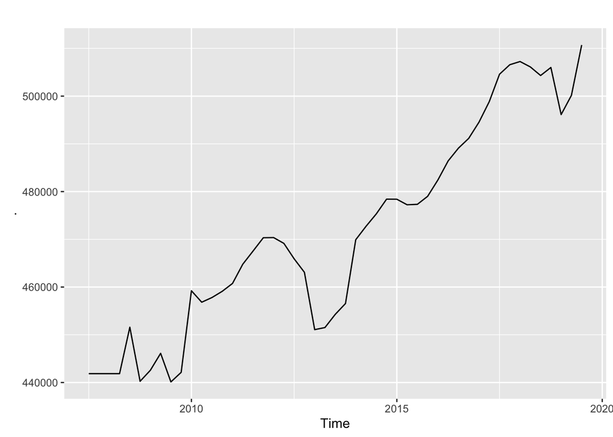

```r
hp.ts <- ts(
  hp.house$MA,
  start=c(2007,3),
  frequency=4
)

hp.ts %>% autoplot()
```

## 2.3 Decompose data time series

`Decompose` terdiri dari beberapa komponen, yaitu Error, Trend, Seasonal. - Trend merupakan pergerakan rata rata (*Moving Average*) secara global - Seasonal adalah pola data per frequency - Error adalah nilai yang tidak dapat oleh Trend dan Seasonal

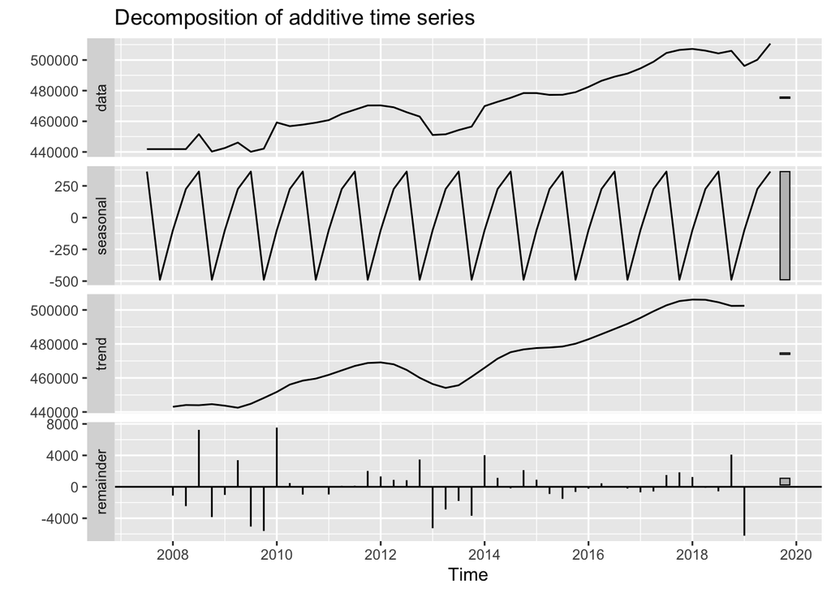

```r
hp.ts %>% decompose() %>% autoplot()
```

Jika dilihat dari data compose diatas, trend Harga rumah bisa dibilang naik, walaupun sempat turun ditahun 2008 dan 2012.

## 2.4 Cross Validation

Salah satu hal yang tidak kalah penting yang harus dilakukan sebelum melalukan modeling adalah Cross Validation. Dimana data akan dipisah menjadi data test dan data train. Hal ini penting karena pemisahan data berfungsi untuk memvalidasi data kita akurat atau tidak saat memprediksi data yang belum pernah dilihat.

```r
hp.test.length <- 4
hp.test <- tail(hp.ts, hp.test.length)
hp.train <- head(hp.ts, length(hp.ts)-length(hp.test))
```

# 3 Modeling

Selanjutnya adalah tahap pembuatan model.

## 3.1 Simple Exponential Smoothing

`Simple Exponentiak Snoothing` merupakan metode forecasting yang digunakan untuk membuat model smoothing exponential smoothing. Tanpa mengandung trend dan seasonal.

```r
hp.ses <- ets(
  hp.train,
  model="ANN"
)
```

## 3.2 Double Exponential Smoothing (Holt)

`Double Exponential Smoothing (Holt)` merupakan metode forecasting yang digunakan untuk membuat model smoothing exponential smoothing. Tanpa mengandung seasonal.

```r
hp.holt <- ets(
  hp.train,
  model="AAN"
)
```

## 3.3 Triple Exponential Smoothing (HoltWinters)

`Triple Exponential Smoothing (HoltWinters)` merupakan metode forecasting yang dikembakan dari metode Holt tetapi mengandung seasonal.

```r
hp.hw <- ets(
  hp.train,
  model="AAA"
)
```

## 3.4 ARIMA

Arima adalah salah satu model forecast yang sering dipakai, salah satu syarat ARIMA adalah data stationer atau mengacak, data yang bergerak disekitar mean atau tidak mempunyai tren dan seasonal.

Model ARIMA :

AR(p) = nilai p menunjukkan berapa banyak data variable y sebelumnya yang digunakan oleh AutoRegressive

I(d) = nilai d menunjukkan berapa kali data dilakukan differencing hingga stationer

MA(q) = nilai q menunjukkan berapa banyak error yang dilakukan smoothing

### 3.4.1 Cek data stationer

Pertama, marilah cek data apakah *stationer* atau bukan.

```r
adf.test(hp.train)
```

```
##
##  Augmented Dickey-Fuller Test
##
## data:  hp.train
## Dickey-Fuller = -3.0967, Lag order = 3, p-value = 0.1387
## alternative hypothesis: stationary
```

```r
adf.test(diff(hp.train, differences = 2))
```

```
##
##  Augmented Dickey-Fuller Test
##
## data:  diff(hp.train, differences = 2)
## Dickey-Fuller = -3.6088, Lag order = 3, p-value = 0.04392
## alternative hypothesis: stationary
```

Pada data ini kita membutuhkan differencing sebesar 2 kali agar p-value kurang dari 0.05.

### 3.4.2 Cek PACF & ACF

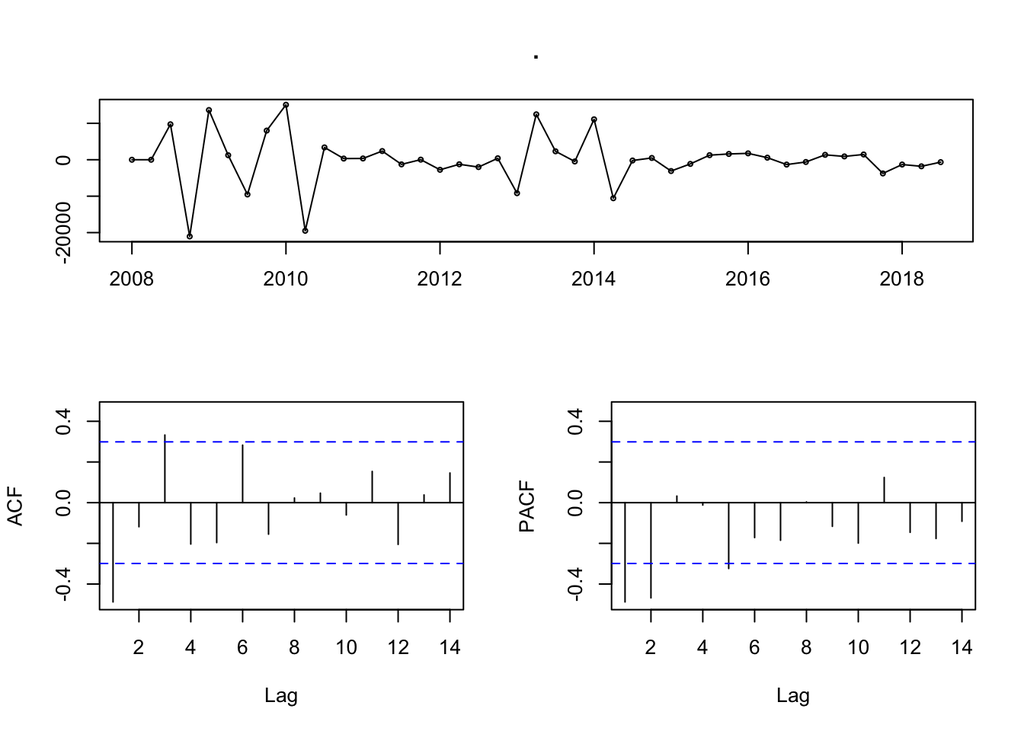

```r
diff(hp.train, differences = 2) %>%
  tsdisplay()
```

Dari hasil plotting ACF, PACF dan differencing, kita mendapatkan nilai untuk tunning model ARIMA. AR(p): 2 I(d): 2 MA(q): 2

### 3.4.3 Tunning model

Untuk model Tunning model, kita akan membuat 3 model.

**1. AR=2, I=2, MA=2**

```r
# 2 2 2
hp.arima.222 <- Arima(hp.train, order=c(2,2,2))
```

**2. AR=2, I=2, MA=1**

```r
# 2 2 1
hp.arima.221 <- Arima(hp.train, order=c(2,2,1))
```

**3. AR=1, I=2, MA=1**

```r
# 1 2 1
hp.arima.121 <- Arima(hp.train, order=c(1,2,1))
```

### 3.4.4 Auto Arima

Jika tadi doatas menggunakan membuat model dengan cara tunning. Kali ini model akan dibuat dengan cara otomatis menggunakan `auto.arima()`

```r
hp.arima.auto <- auto.arima(hp.train)
```

### 3.4.5 Error

```r
accuracy(hp.ses)
```

```
##                    ME     RMSE      MAE       MPE      MAPE      MASE
## Training set 1387.922 4968.771 3304.427 0.2879184 0.7107922 0.3292605
##                      ACF1
## Training set -0.004036374
```

```r
accuracy(hp.holt)
```

```
##                    ME     RMSE      MAE        MPE     MAPE      MASE
## Training set 213.4037 4785.528 3102.021 0.03652971 0.670119 0.3090924
##                      ACF1
## Training set -0.002455833
```

```r
accuracy(hp.hw)
```

```
##                    ME   RMSE      MAE        MPE     MAPE      MASE       ACF1
## Training set 96.31423 4707.8 3262.854 0.01185402 0.703742 0.3251181 0.01851541
```

```r
accuracy(hp.arima.222)
```

```
##                    ME     RMSE      MAE        MPE     MAPE      MASE
## Training set 394.6464 4726.398 3048.461 0.07897832 0.657617 0.3037555
##                    ACF1
## Training set -0.0115943
```

```r
accuracy(hp.arima.221)
```

```
##                    ME     RMSE      MAE        MPE      MAPE     MASE
## Training set 356.5656 4766.795 3037.537 0.07101273 0.6557748 0.302667
##                     ACF1
## Training set -0.02095751
```

```r
accuracy(hp.arima.121)
```

```
##                   ME     RMSE      MAE        MPE      MAPE     MASE
## Training set 352.313 4768.366 3039.845 0.07019384 0.6563477 0.302897
##                     ACF1
## Training set -0.02298624
```

```r
accuracy(hp.arima.auto)
```

```
##                    ME     RMSE      MAE         MPE      MAPE      MASE
## Training set -3.10017 4534.454 2914.371 -0.01221927 0.6313192 0.2903945
##                     ACF1
## Training set -0.06223442
```

# 4 Forecasting

Setelah modeling, selanjutnya adalah forecasting. Model yang akan digunakan adalah model Auto Arima karena memiliki error paling kecil atau `MAPE` sebebesar 0.63

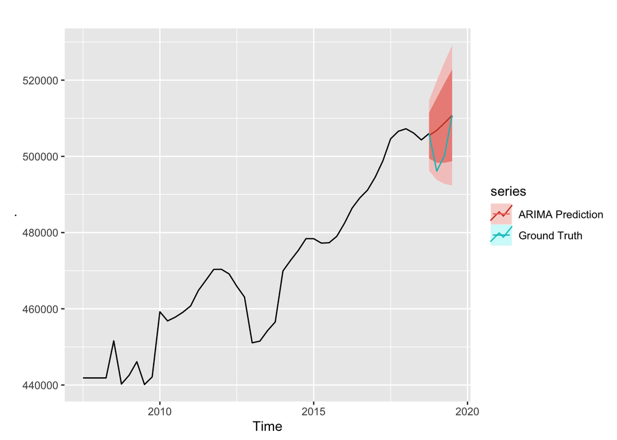

```r
hp.arima.forecast <- forecast(hp.arima.auto, h=hp.test.length)

hp.ts %>% autoplot() +
  autolayer(hp.arima.forecast, series = "ARIMA Prediction") +
  autolayer(hp.test, series = "Ground Truth")
```

Dari hasil forecasting diatas, bisa dilihat data model ARIMA dapat memprediksi harga lumayan akurat walaupun sempat salah prediksi yang lumayan besar di tahun 2019.

# 5 Evaluation

## 5.1 Error

```r
accuracy(hp.arima.forecast, hp.test)
```

```
##                       ME     RMSE      MAE         MPE      MAPE      MASE
## Training set    -3.10017 4534.454 2914.371 -0.01221927 0.6313192 0.2903945
## Test set     -4691.44662 6860.306 4962.704 -0.94260570 0.9962137 0.4944950
##                     ACF1 Theil's U
## Training set -0.06223442        NA
## Test set     -0.26121775 0.9146089
```

## 5.2 Assumption check

Ada beberapa asumsi yang akan digunakan untuk mengecek model, yaitu **No-autocorrelation residual** dan cek **Normal Distribution**.

### 5.2.1 No-autocorrelation residual

H0 : residual has no-autocorrelation H1: residual has autocorrelation yang diinginkan p-value > 0.05 (alpha), no-autocorrelation

```r
Box.test(x = hp.arima.forecast$residuals, type = "Ljung-Box")
```

```
##
##  Box-Ljung test
##
## data:  hp.arima.forecast$residuals
## X-squared = 0.18617, df = 1, p-value = 0.6661
```

Untuk cek asumsi no-autocorrelation residual, mendapatkan `p-value` sebesar 0.66 atau p-value > 0.5 yang berarti no-autocorrelation atau terima H0

### 5.2.2 Normal Distribution

H0 : residual menyebar normal H1: residual tidak menyebar normal yang diinginkan p-value > 0.05 (alpha), residual menyebar normal

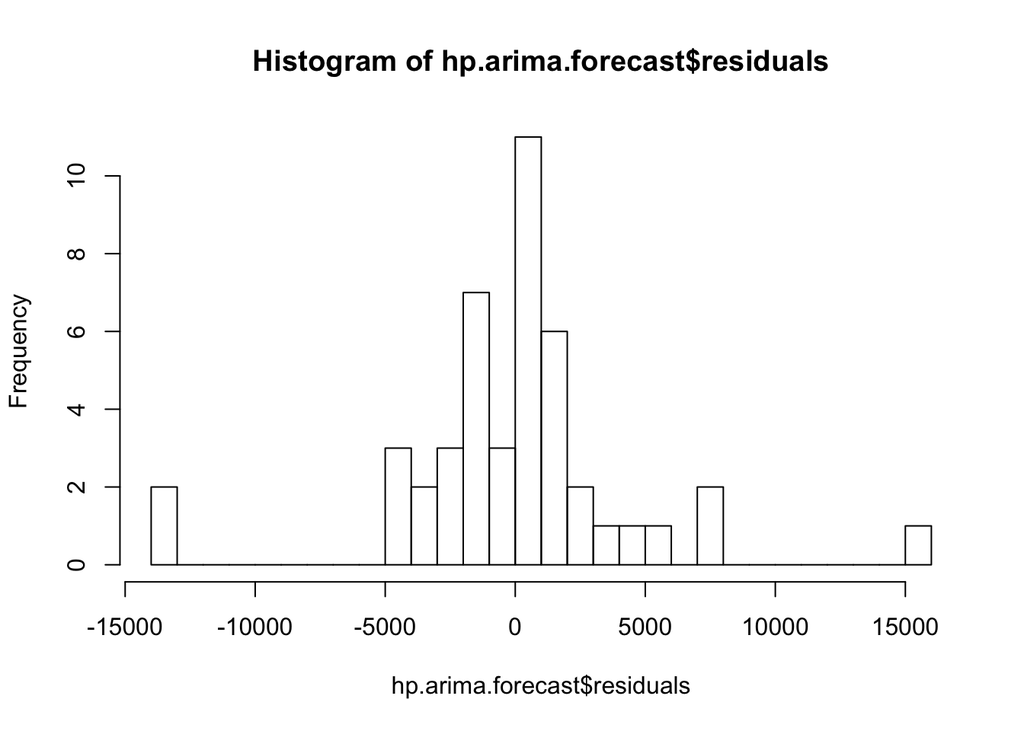

```r
hist(hp.arima.forecast$residuals, breaks = 30)
```

```r
shapiro.test(x = hp.arima.forecast$residuals)
```

```
##
##  Shapiro-Wilk normality test
##
## data:  hp.arima.forecast$residuals
## W = 0.87352, p-value = 0.0001566
```

Dari hasil diatas, didapatkan p-value 0.0001566 atau p-value < 0.05 yang berarti residual tidak menyebar normal atau tolak H0

# 6 Conclusion

Dari hasil evaluasi model dapat disimpulkan bahwa model Auto Arima adalah yang terbaik dan dari tes asumsi tidak memiliki autocorrelation tetapi residual tidak menyebar normal.